# finalProject

```python
import numpy as np
import matplotlib as plt
import pandas as pd
import math
```

1. Which Surnames had multiple differnet people get Nobel Awards?
2. How many Nobel Awards did each country get?
3. How old did the average Nobel Award Laureate live to?
4. Which city had the most awards for each discipline?
5. Which year were the most Nobel Laureates alive in?
6. Which Laureates were part of a University when awarded the Award?

Load your data set into a Pandas data frame and do some preprocessing and cleaning if needed (this should be documented)

```python
nobelDF = pd.read_csv('export.csv')
```

```python
nobelDF
```

|  | id | firstname | surname | born | died | bornCountry | bornCountryCode | bornCity | diedCountry | diedCountryCode | diedCity | gender | year | category | overallMotivation | share | motivation | name | city | country |
| --- | --- | --- | --- | --- | --- | --- | --- | --- | --- | --- | --- | --- | --- | --- | --- | --- | --- | --- | --- | --- |
| 0 | 1 | Wilhelm Conrad | Röntgen | 1845-03-27 | 1923-02-10 | Prussia (now Germany) | DE | Lennep (now Remscheid) | Germany | DE | Munich | male | 1901 | physics | NaN | 1 | "in recognition of the extraordinary services ... | Munich University | Munich | Germany |
| 1 | 2 | Hendrik A. | Lorentz | 1853-07-18 | 1928-02-04 | the Netherlands | NL | Arnhem | the Netherlands | NL | NaN | male | 1902 | physics | NaN | 2 | "in recognition of the extraordinary service t... | Leiden University | Leiden | the Netherlands |
| 2 | 3 | Pieter | Zeeman | 1865-05-25 | 1943-10-09 | the Netherlands | NL | Zonnemaire | the Netherlands | NL | Amsterdam | male | 1902 | physics | NaN | 2 | "in recognition of the extraordinary service t... | Amsterdam University | Amsterdam | the Netherlands |
| 3 | 4 | Henri | Becquerel | 1852-12-15 | 1908-08-25 | France | FR | Paris | France | FR | NaN | male | 1903 | physics | NaN | 2 | "in recognition of the extraordinary services ... | École Polytechnique | Paris | France |
| 4 | 5 | Pierre | Curie | 1859-05-15 | 1906-04-19 | France | FR | Paris | France | FR | Paris | male | 1903 | physics | NaN | 4 | "in recognition of the extraordinary services ... | École municipale de physique et de chimie indu... | Paris | France |
| ... | ... | ... | ... | ... | ... | ... | ... | ... | ... | ... | ... | ... | ... | ... | ... | ... | ... | ... | ... | ... |
| 995 | 1030 | Louis | Brus | 1943-00-00 | 0000-00-00 | USA | US | Cleveland OH | NaN | NaN | NaN | male | 2023 | chemistry | NaN | 3 | "for the discovery and synthesis of quantum dots" | Columbia University | New York NY | USA |
| 996 | 1031 | Aleksey | Yekimov | 1945-00-00 | 0000-00-00 | USSR (now Russia) | RU | Leningrad (now St. Petersburg) | NaN | NaN | NaN | male | 2023 | chemistry | NaN | 3 | "for the discovery and synthesis of quantum dots" | Nanocrystals Technology Inc. | New York NY | USA |
| 997 | 1032 | Jon | Fosse | 1959-09-29 | 0000-00-00 | Norway | NO | Haugesund | NaN | NaN | NaN | male | 2023 | literature | NaN | 1 | "for his innovative plays and prose which give... | NaN | NaN | NaN |
| 998 | 1033 | Narges | Mohammadi | 1972-04-21 | 0000-00-00 | Iran | IR | Zanjan | NaN | NaN | NaN | female | 2023 | peace | NaN | 1 | "for her fight against the oppression of women... | NaN | NaN | NaN |
| 999 | 1034 | Claudia | Goldin | 1946-00-00 | 0000-00-00 | USA | US | New York NY | NaN | NaN | NaN | female | 2023 | economics | NaN | 1 | "for having advanced our understanding of wome... | Harvard University | Cambridge MA | USA |

1000 rows × 20 columns

Perform exploratory data analysis & visualization

Map your questions as queries on the Pandas dataframe to generate answers

1. Which Surnames had multiple different people get Nobel Awards?

```python
surnamesDict = {}
uniqueSurnames = list(nobelDF['surname'].unique())
for surname in uniqueSurnames:
    if isinstance(surname,str):

        #including those with two last names such as in the case of: Irène,Joliot-Curie
        surnameList = nobelDF.loc[(nobelDF['surname'] == surname) | (nobelDF['surname'].str.contains('-' + surname, na=False)) | (nobelDF['surname'].str.contains(surname + '-', na=False))]

        #not allowing duplicate people with the same first name (this could possibly have an error if there are people with the same first & last name, as first names are not always unique)
        firstNameList = []
        surnamesDict[surname] = 0
        for firstName in surnameList['firstname']:
            if firstName not in firstNameList:
                surnamesDict[surname] += 1
            firstNameList.append(firstName)

        surnamesDict[surname] = [surnamesDict[surname]]

surnamesDF = pd.DataFrame.from_dict(surnamesDict)
surnamesDF.T.loc[surnamesDF.T[0] != 1].sort_values(by=0,ascending=False)
```

|  | 0 |
| --- | --- |
| Smith | 5 |
| Wilson | 5 |
| Fischer | 4 |
| Lee | 3 |
| Lewis | 3 |
| Müller | 3 |
| Curie | 3 |
| Buck | 2 |
| Mann | 2 |
| Kornberg | 2 |
| von Euler | 2 |
| Tinbergen | 2 |
| Wiesel | 2 |
| Cohen | 2 |
| Diamond | 2 |
| Hall | 2 |
| Murad | 2 |
| Henderson | 2 |
| Frank | 2 |
| Marshall | 2 |
| Krebs | 2 |
| Myrdal | 2 |
| Simon | 2 |
| Mistral | 2 |
| Williams | 2 |
| Hoffmann | 2 |
| Cori | 2 |
| Thomson | 2 |
| Bragg | 2 |
| Bohr | 2 |
| Siegbahn | 2 |
| Richardson | 2 |
| Hess | 2 |
| Anderson | 2 |
| Bloch | 2 |
| Chamberlain | 2 |
| Jensen | 2 |
| Mott | 2 |
| Friedman | 2 |
| Kendall | 2 |
| Richards | 2 |
| Joliot | 2 |
| Hodgkin | 2 |
| Porter | 2 |
| Brown | 2 |
| Moser | 2 |

It's both interesting to see familiar last names in this list with > 1 unique person with last names such as Bohr, Krebs and Curie giving off an idea that it was common for these successful people to raise their children to also be successful scientists in these fields. It can also be used to give more insight to the culture of different people, you can see that german surnames are very common such as: Fischer or Muller.

2. How many Nobel Awards did each country get?

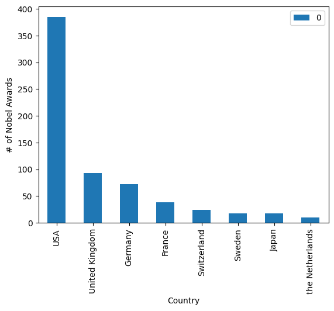

```python
uniqueCountries = list(nobelDF['country'].unique())
countriesDict = {}
for country in uniqueCountries:
    countriesDict[country] = [len(nobelDF.loc[nobelDF['country'] == country])]

countriesDF = pd.DataFrame.from_dict(countriesDict)
displayCountries = countriesDF.T.loc[countriesDF.T[0] != 1].sort_values(by=0,ascending=False).head(8)
displayCountries.plot.bar(xlabel='Country', ylabel='# of Nobel Awards')
```

This is interesting as I believed the graph would be much more evenly spread but from this it looks like the USA has more Noble Laureates than the next 7 countries all combined. This does make sense though because the USA has much more population than the UK, Germany, France, Sweden & the Netherlands combined. It might be interesting to see a graph of this from just the past 10 years, or seeing a graph of # of Nobel Awards per Capita.

3. How old did the average Nobel Award Laureate live to?

```python
yearsDF = nobelDF.loc[((nobelDF['born'].notnull()) & (nobelDF['born'] != '0000-00-00')) & ((nobelDF['died'].notnull()) & (nobelDF['died'] != '0000-00-00')),['born','died']].stack()
ageList = []
for i in range(len(yearsDF) // 2):
    #print(nobelDF[['born','died','firstname']].T[i*2])

    #Just getting the year from their dates
    ageList.append(int(list(yearsDF)[(i*2)+1][0:4]) - int(list(yearsDF)[(i*2)][0:4]))

    #Used in testing to make sure there are no errors
    if ageList[-1] < 18:
        print(i)
        print(int(list(yearsDF)[(i*2)][0:4]), int(list(yearsDF)[(i*2)+1][0:4]))
    #print(nobelDF[['born','died','firstname']].T[(i*2) + 1])

avgAge = (sum(ageList) / len(ageList))
print(avgAge)
```

```
81.02232142857143
```

This is a very interesting information as the average life expectancy of a nobel Laureate is is much higher than that of the life expectancy from their time periods. It can be assumed that the Laureates lived quite comfortably in that they were able to be successful in the sciences enough to be awarded the Nobel Prize. This gives some insight that wealthier people had a much higher life expectancy than those not as lucky in the 20th century. It is also true that being a Laureate means that you most likely did not serve in a very dangerous career (such as in the army) and it also means that you did not die very young whereas many smart people capable of being a Laureate could have died in childhood or serving their country in a mandatory draft.

[figure not shown]

4. Which city had the most awards for each discipline?

```python
disciplinesList = list(nobelDF['category'].unique())
disciplinesDict = {}
uniqueCities = list(nobelDF['city'].unique())
for discipline in disciplinesList:
    thisDisciplineCityList = {}
    for city in uniqueCities:
        thisDisciplineCityList[city] = [len(nobelDF.loc[(nobelDF['city'] == city) & (nobelDF['category'] == discipline)])]
    disciplinesDict[discipline] = pd.DataFrame(thisDisciplineCityList)
for discipline in disciplinesDict:
    print('discipline: ', discipline)
    print('top city: ', str(disciplinesDict[discipline].T.sort_values(by=0,ascending=False).head(1)[0]).split('  ')[0])
```

```
discipline:  physics
top city:  Cambridge MA
discipline:  chemistry
top city:  Cambridge
discipline:  peace
top city:  Paris
discipline:  medicine
top city:  New York NY
discipline:  literature
top city:  Munich
discipline:  economics
top city:  Cambridge MA
```

5. Which year were the most Nobel Laureates alive in?

```python
#Ignore any that have not died yet / have unknown births
yearsDF = nobelDF.loc[((nobelDF['born'].notnull()) & (nobelDF['born'] != '0000-00-00')) & ((nobelDF['died'].notnull()) & (nobelDF['died'] != '0000-00-00')),['born','died']]

birthsList = list(nobelDF['born'])
deathsList = list(nobelDF['died'])
yearsDict = {}
for i in range(len(birthsList)):
    if (isinstance(birthsList[i], str) & isinstance(deathsList[i], str)):
        birthYear = int(birthsList[i][:4])
        deathYear = int(deathsList[i][:4])
        for year in range(birthYear,deathYear + 1):
            if year not in yearsDict:
                yearsDict[year] = 0
            yearsDict[year] += 1
for i in yearsDict:
    yearsDict[i] = [yearsDict[i]]
yearsDF = pd.DataFrame(yearsDict)
yearsDF.T.loc[yearsDF.T[0] != 1].sort_values(by=0,ascending=False)
```

|  | 0 |
| --- | --- |
| 1934 | 559 |
| 1936 | 558 |
| 1935 | 557 |
| 1940 | 557 |
| 1933 | 556 |
| ... | ... |
| 1823 | 2 |
| 1824 | 2 |
| 1825 | 2 |
| 1826 | 2 |
| 1827 | 2 |

203 rows × 1 columns

It is very curious as to why there are the most Laureates alive just around the start of the second world war. It would be interesting to see how many of them were adults during the war and how many of them were young children. It would also be interesting to see what countries those who lived through world war 2 were home too. I suspect the reason for why the majority of them being alive in this time period is those who were just born in that time may be just starting to run out judging by the average age of the Laureates and in my querry I decided to not include those who were still alive right now. If I were to redo this experiment I would change this by setting their death to current day.

6. Which Laureates were part of a School when awarded the Award?

```python
print(len(nobelDF.loc[(nobelDF['name'].str.contains('University', na=False)) | (nobelDF['name'].str.contains('College', na=False)) | (nobelDF['name'].str.contains('School', na=False))]), '/', len(nobelDF))
```

```
474 / 1000
```

While the majority of Laureates were not in a school when awarded, there are a very large percentage of them that are (47%). I am surprised it was not more as schools are usually the leaders around the world for research and I would imagine that the breakthroughs that result in being awarded with a Nobel Prize are only discoverable through years of research. I am certain that whichever industries the Laureates worked for did pay much better than what they would get working for a University though. It would be interesting to see what percent of Laureates were part of a government funded entity such as for example, NASA.

Communicates those insights as actionable text or a story that may be easy to communicate and share with others interested in the same dataset.